# GP_Evaluation4_3

Yuanxi Cheng

2022-09-11

## Evaluation of Total Player Population Vs Average Annual Humidity in the Afternoon

### Map of Average Humidity in percent

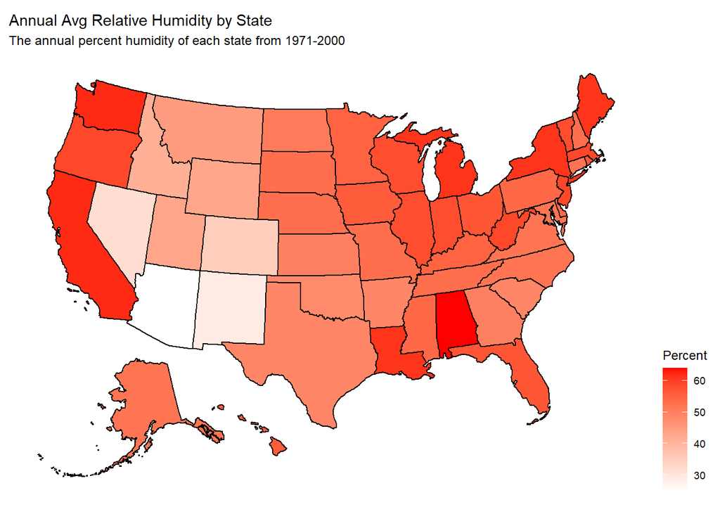

[figure not shown]

## Scatter Plots

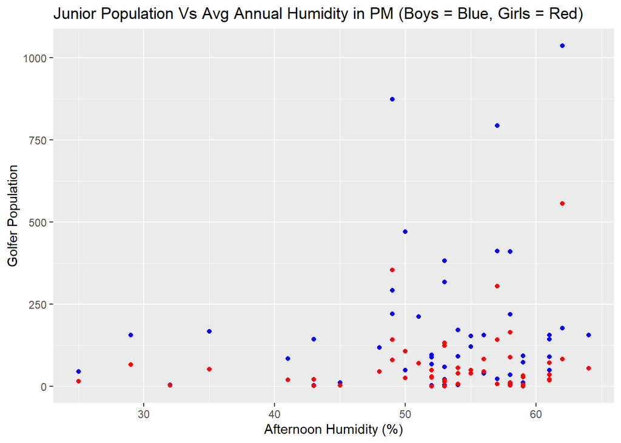

### Fitting Linear Models (Not Standardized Population)

### Boys:

#### Linear Regression Line

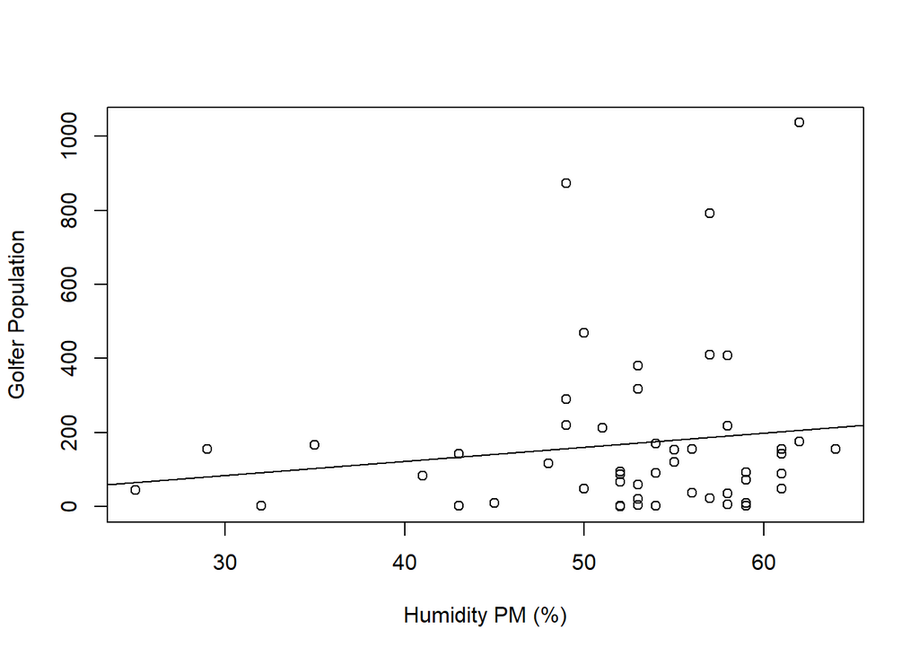

#### Analyzing Residuals and Testing Regression:

```
##
## Call:
## lm(formula = y ~ x, data = boysVsAfterHum)
##
## Residuals:
##     Min      1Q  Median      3Q     Max
## -192.60 -131.97  -59.82   42.54  831.05
##
## Coefficients:
##             Estimate Std. Error t value Pr(>|t|)
## (Intercept)  -28.594    199.453  -0.143    0.887
## x              3.783      3.760   1.006    0.319
##
## Residual standard error: 221.6 on 48 degrees of freedom
## Multiple R-squared:  0.02065,    Adjusted R-squared:  0.0002452
## F-statistic: 1.012 on 1 and 48 DF,  p-value: 0.3195
```

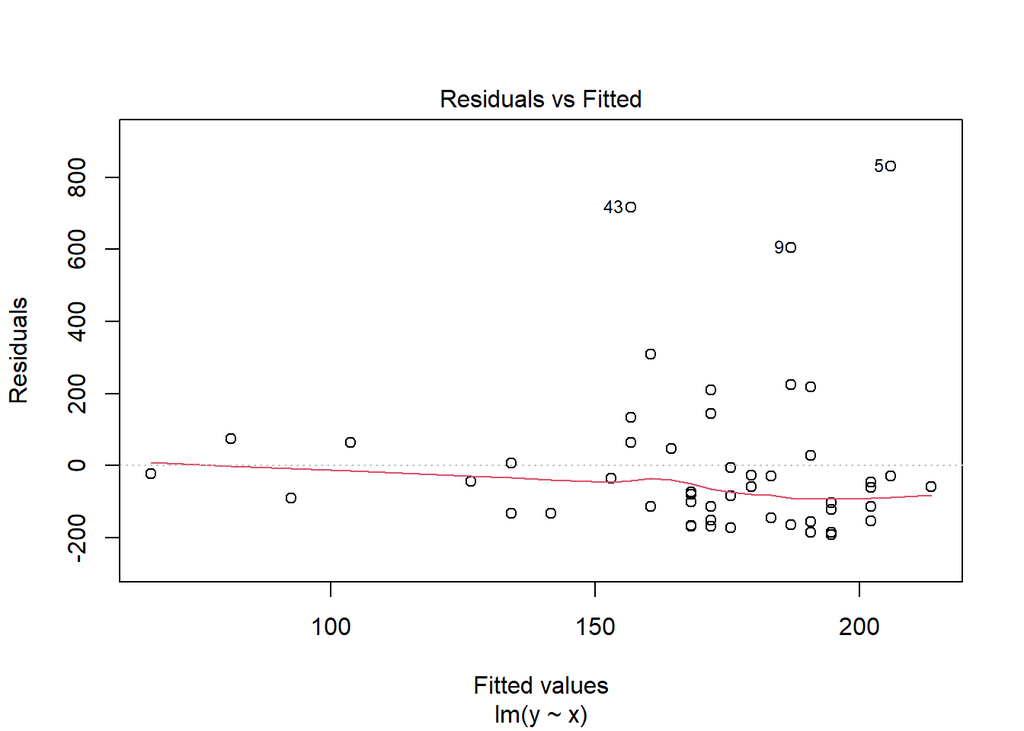

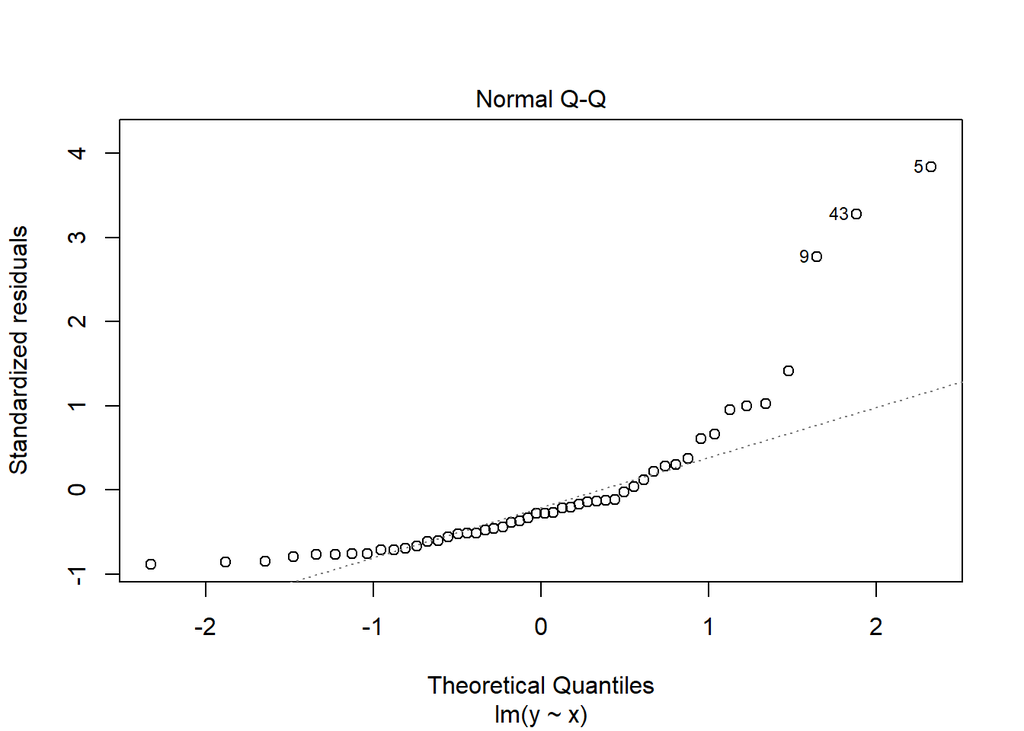

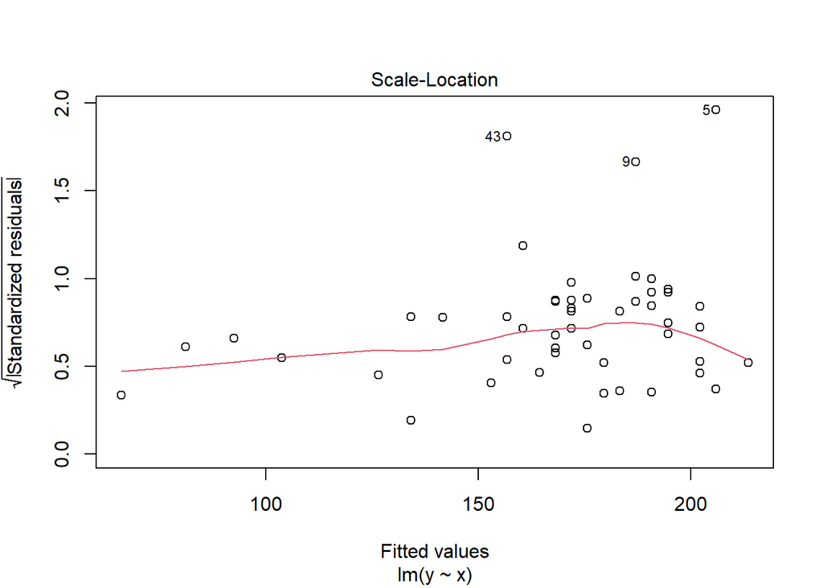

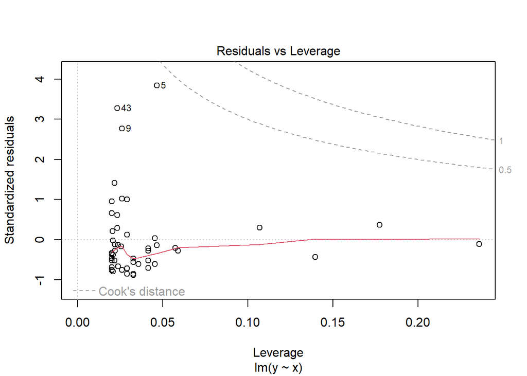

### Girls:

#### Linear Regression Line

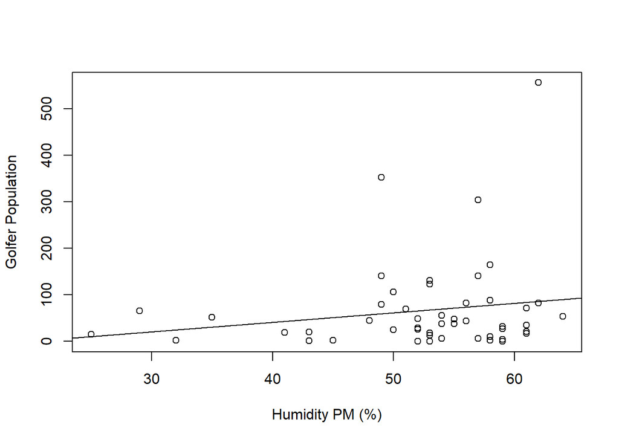

#### Analyzing Residuals and Testing Regression:

```
##
## Call:
## lm(formula = y ~ x, data = girlsVsAfterHum)
##
## Residuals:
##    Min     1Q Median     3Q    Max
## -79.74 -51.92 -28.31   9.83 470.13
##
## Coefficients:
##             Estimate Std. Error t value Pr(>|t|)
## (Intercept)  -40.922     89.249  -0.459    0.649
## x              2.045      1.683   1.215    0.230
##
## Residual standard error: 99.18 on 48 degrees of freedom
## Multiple R-squared:  0.02985,    Adjusted R-squared:  0.009643
## F-statistic: 1.477 on 1 and 48 DF,  p-value: 0.2302
```

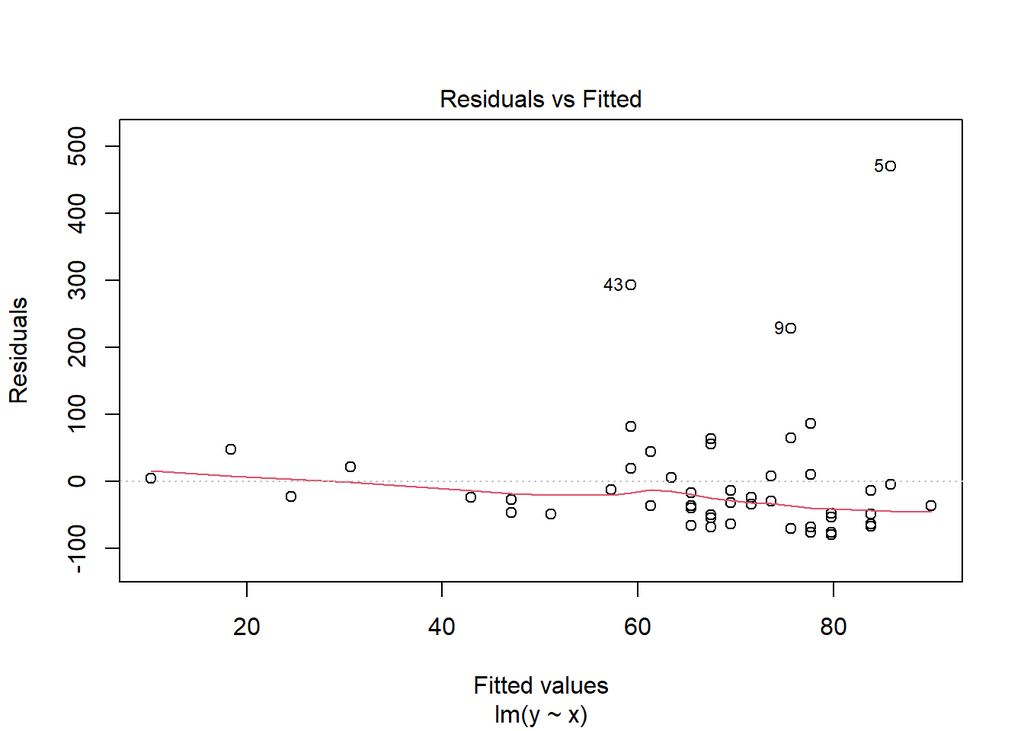

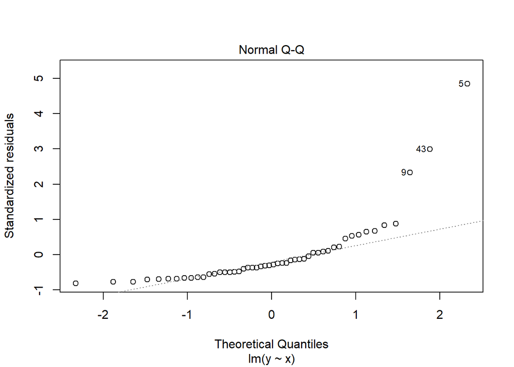

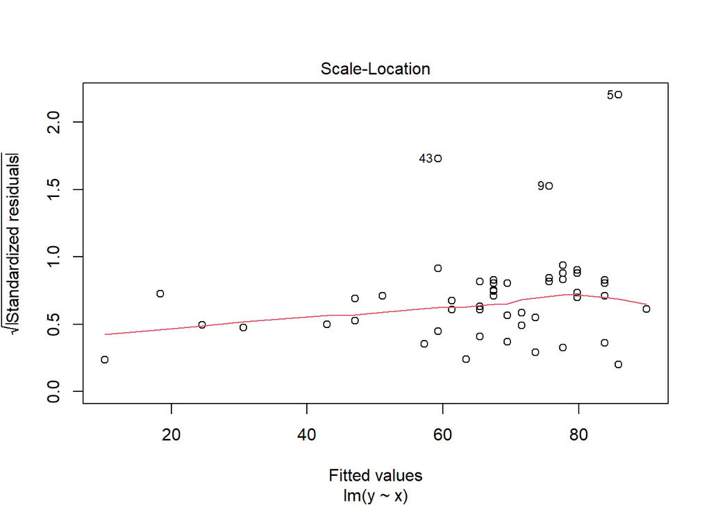

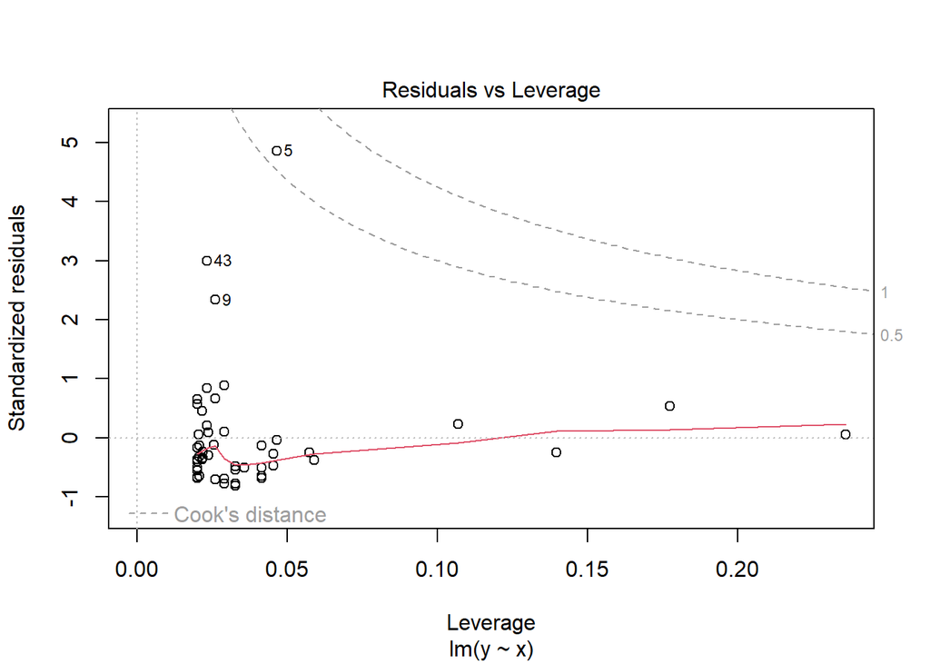

### Linear Modeling Results - Negative

#### The lm() function in R creates a regression model with the given data, and the summary functions reviews the weights and performance measures of the model. The residuals allows us to measure and analyze the difference between prediction and actual results of the linear model. In this project, residuals, along with the p-value, are observed and tested to see how well the single-variable linear regression model fits the data.

#### Weather is another factor that logically seems like a big factor to the popularity of golf. Humidity should be a factor of golf popularity, as it often affects the conditions of golf courses, which int turn may affect the incentives for people to play golf or not. Looking at the scatterplot shows that the data is heavily skewed left, with higher population concentrations in the 50 to 65 percent range. The p value of the linear regression model is above 0.05, so therefore humidity is not a linear predictor of golf popularity.

#### Humidity is ultimately not a significant factor of golf population, at least in a linear apparatus. The truth is that weather shouldn’t logically be a linear relationship with golfer population, and it goes to show the limits of linear modeling. The reality is that many scenarios and factors are much more complicated than linear relationships, which is a good thing to understand.